# 모터-감속기 이상 탐지 — 학습 파이프라인 (Stage 2~4)

## (D) 12채널 융합 A/B 비교 — 선택 실험

**왜 하나?** 현재 센서 분리(late fusion: 센서별 모델 → 확률을 `0.6평균+0.4최고` 로 합침)는 **센서 간 결합 정보**와 **적응형 가중치**를 포기한 트레이드오프다. 어떤 고장은 *전류 패턴 + 진동 패턴이 같이 나타나는 조합*으로만 구별되는데, 따로 예측해 나중에 합치면 그 결합을 못 쓴다. 또 고정 가중치(0.6/0.4)는 고장마다 어떤 센서가 중요한지 자동으로 못 바꾼다.

**대안:** 한 세션의 3센서를 **채널로 쌓아**(3센서 × 4피처 = 12채널) 한 모델에 한 샘플로 넣는다. `MiniRocketMultivariate` 는 채널 수와 무관하게 받으므로 코드 변경이 작다. 이러면 한 모델이 센서를 **동시에** 보고 결합 정보를 학습한다.

**대전제:** 3센서가 **시간 정렬**돼 있어야 채널로 쌓을 수 있다. 그래서 **먼저 정렬 점검부터** 한다 — 짝이 충분치 않으면 융합 샘플을 못 만든다.

### (D-1) 정렬 점검 — 3센서가 짝지어지는 세션이 충분한가

`group_key` 에서 센서 부분만 떼면 **세션 키**가 된다. 세션마다 3센서(`Current_U`, `Vib_Motor`, `Vib_TM`)가 다 있는지 세어, **융합에 쓸 수 있는 세션 수**와 **짝이 안 맞아 버려질 세션 수**를 먼저 확인한다. 이 숫자가 충분하면 (D-2)로 진행, 적으면 융합은 보류하고 "향후 방향" 슬라이드로 남긴다.

```python
import pandas as pd, glob, os
from collections import defaultdict

SENSORS = ["Current_U", "Vib_Motor", "Vib_TM"]

def session_key_of(group_key, sensor):
    suffix = "_" + sensor
    return group_key[:-len(suffix)] if group_key.endswith(suffix) else group_key

# CSV_ROOT 아래 모든 CSV 의 (vehicle, fault_class, session_key) 별 센서 집합 수집
rows = []
for path in glob.glob(os.path.join(CSV_ROOT, "**", "*.csv"), recursive=True):
    # 메타만 빠르게: 첫 행만 읽어 컬럼 확인 후 필요한 컬럼만
    head = pd.read_csv(path, nrows=1)
    need = ["group_key", "vehicle", "fault_class", "sensor"]
    if not set(need) <= set(head.columns):
        continue
    r = head.iloc[0]
    sk = session_key_of(str(r["group_key"]), str(r["sensor"]))
    rows.append((r["vehicle"], r["fault_class"], sk, r["sensor"]))

df = pd.DataFrame(rows, columns=["vehicle", "fault_class", "session", "sensor"])
sess = df.groupby(["vehicle", "fault_class", "session"])["sensor"].apply(set)

complete = sess[sess.apply(lambda s: set(SENSORS) <= s)]
partial  = sess[sess.apply(lambda s: not (set(SENSORS) <= s))]

print(f"전체 세션 수        : {len(sess):,}")
print(f"3센서 완비(융합 가능): {len(complete):,}")
print(f"짝 안맞아 버려짐     : {len(partial):,}")
print("\n차종×결함별 융합 가능 세션 수:")
print(complete.reset_index().groupby(["vehicle", "fault_class"]).size())
```

```
전체 세션 수        : 12,720
3센서 완비(융합 가능): 12,720
짝 안맞아 버려짐     : 0

차종×결함별 융합 가능 세션 수:
vehicle  fault_class
IONIQ    DEMAG           626
         ECC10           826
         ECC20          1038
         NORMAL          764
         REDUC          1975
KONA     DEMAG           617
         ECC10           577
         ECC20           732
         NORMAL          703
         REDUC          1078
NIRO     DEMAG           697
         ECC10           528
         ECC20           807
         NORMAL          582
         REDUC          1170
dtype: int64
```

```python
import pandas as pd, glob, os

SENSORS = ["Current_U", "Vib_Motor", "Vib_TM"]

def session_key_of(group_key, sensor):
    suffix = "_" + sensor
    return group_key[:-len(suffix)] if group_key.endswith(suffix) else group_key

# CSV 하나 골라서 세션 키 뽑기
sample_csv = glob.glob(os.path.join(CSV_ROOT, "**", "*.csv"), recursive=True)[0]
head = pd.read_csv(sample_csv, nrows=1).iloc[0]
sess = session_key_of(str(head["group_key"]), str(head["sensor"]))
print("샘플 세션 키:", sess)

# 그 세션의 3센서 CSV 찾아서 각각 행 수 확인
for path in glob.glob(os.path.join(CSV_ROOT, "**", "*.csv"), recursive=True):
    h = pd.read_csv(path, nrows=1).iloc[0]
    if session_key_of(str(h["group_key"]), str(h["sensor"])) == sess:
        n = len(pd.read_csv(path))
        print(f"  {h['sensor']:12s} 행수={n}  파일={os.path.basename(path)}")
```

```
샘플 세션 키: 22_06_09_12_26_53_01_zsplit001
  Current_U    행수=190000  파일=22_06_09_12_26_53_01_zsplit001_Current_U_timeseries.csv
  Vib_Motor    행수=190000  파일=22_06_09_12_26_53_01_zsplit001_Vib_Motor_timeseries.csv
  Vib_TM       행수=190000  파일=22_06_09_12_26_53_01_zsplit001_Vib_TM_timeseries.csv
```

```python
import inspect
print(inspect.getsource(load_slot_chunks))
```

```
def load_slot_chunks(paths):
    """
    슬롯에 속한 CSV 들을 읽어 청크 단위 샘플로 변환.
    반환: X (n_chunks, C, CHUNK_SIZE), y (n_chunks,), groups (n_chunks,) | None
    각 청크의 label = 해당 CSV 의 fault_class, group = group_key (누수 방지용).
    """
    Xs, ys, gs = [], [], []
    for p in paths:
        try:
            df = pd.read_csv(p)
        except Exception as e:
            print("스킵(읽기 실패):", p, "→", e); continue
        if df.empty:
            continue
        feats = df[FEATURE_COLS].to_numpy(dtype=np.float32)     # (n, C)
        n = (len(feats) // CHUNK_SIZE) * CHUNK_SIZE             # 끝의 잔여행(<2000) 버림
        if n == 0:
            continue
        C = feats.shape[1]
        chunks = feats[:n].T.reshape(C, -1, CHUNK_SIZE).transpose(1, 0, 2)  # (n_chunks, C, L)
        label = str(df["fault_class"].iloc[0])
        group = str(df["group_key"].iloc[0])
        Xs.append(chunks)
        ys += [label] * len(chunks)
        gs += [group] * len(chunks)
    if not Xs:
        return None
    return np.concatenate(Xs, 0), np.array(ys), np.array(gs)
```

# (D-2) 12채널 융합 학습 + late vs early A/B 비교

**(D-1) 통과 확인:** 전체 12,720 세션 = 3센서 완비 12,720 (버려짐 0). 3센서 길이 동일(190,000) → **crop 불필요, 손실 0**.

**무엇을 하나:** 같은 세션의 3센서를 **12채널(4피처×3센서)** 로 쌓아 한 모델에 넣는 *early fusion* 모델을 차종별로 학습하고, 기존 *late fusion*(센서 분리 + 0.6평균/0.4최고)의 macro-F1 과 비교한다.

**기존 자산 재사용:**

- 청크화 방식은 `load_slot_chunks` 와 동일 (`(n_chunks, C, CHUNK_SIZE)`, C=12).
- `train_slot` 을 **그대로** 호출 → `make_minirocket` 이 채널 12 를 보고 자동으로 `MiniRocketMultivariate` 사용.
- 셀 1(가속)의 lbfgs·F캐시도 그대로 적용됨.
- group = **세션 키**(센서 제거) → 누수 방지.

> 전제: 앞서 (D-1)/가속 셀에서 `SENSORS`, `session_key_of`, `FEATURE_COLS`, `CHUNK_SIZE`, `train_slot`, `CSV_ROOT` 가 이미 정의돼 있어야 한다.

## (D-2-a) 세션 인덱스 구축 — 차종별로 세션→3센서 CSV 경로 매핑

먼저 모든 CSV 를 훑어 `(vehicle, fault_class, session)` 마다 3센서 경로를 모은다. 이 인덱스를 (D-2-b) 빌더가 사용한다.

```python
import glob, os, pandas as pd
from collections import defaultdict

# (vehicle, session) -> {sensor: path, ...},  라벨도 함께 보관
session_index = defaultdict(dict)        # key=(vehicle, session) -> {sensor: path}
session_label = {}                       # key=(vehicle, session) -> fault_class

for path in glob.glob(os.path.join(CSV_ROOT, "**", "*.csv"), recursive=True):
    h = pd.read_csv(path, nrows=1)
    need = ["group_key", "vehicle", "fault_class", "sensor"]
    if not set(need) <= set(h.columns):
        continue
    r = h.iloc[0]
    vehicle = str(r["vehicle"]); sensor = str(r["sensor"])
    sess = session_key_of(str(r["group_key"]), sensor)
    session_index[(vehicle, sess)][sensor] = path
    session_label[(vehicle, sess)] = str(r["fault_class"])

# 3센서 완비 세션만 차종별로 집계
from collections import Counter
by_vehicle = defaultdict(list)
for (vehicle, sess), smap in session_index.items():
    if set(SENSORS) <= set(smap):                 # 3센서 다 있는 세션만
        by_vehicle[vehicle].append(sess)

print("차종별 융합 가능 세션 수:")
for v in sorted(by_vehicle):
    print(f"  {v}: {len(by_vehicle[v]):,} 세션")
```

```
차종별 융합 가능 세션 수:
  IONIQ: 5,229 세션
  KONA: 3,707 세션
  NIRO: 3,784 세션
```

## (D-2-b) 12채널 융합 청크 빌더

세션 하나당: 3센서 CSV 를 읽어 4피처씩 → 12채널로 가로 결합 → `load_slot_chunks` 와 동일하게 청크화.

- label = 세션의 fault_class
- group = 세션 키 (같은 세션 청크는 한쪽 split 에만 → 누수 방지)
- 길이가 혹시 다르면 가장 짧은 센서에 맞춰 crop (현재 데이터는 동일해서 발생 안 함)

```python
import numpy as np

def _chunkify(feats, chunk_size):                 # feats: (n, C) -> (n_chunks, C, L)
    n = (len(feats) // chunk_size) * chunk_size
    if n == 0:
        return None
    C = feats.shape[1]
    return feats[:n].T.reshape(C, -1, chunk_size).transpose(1, 0, 2)

def build_vehicle_fusion(vehicle, sessions):
    # 차종 1대의 모든 완비 세션 -> (X12, y, groups). X12: (N, 12, CHUNK_SIZE)
    Xs, ys, gs = [], [], []
    for sess in sessions:
        smap = session_index[(vehicle, sess)]
        # 센서별 4피처 로드
        feats_by_sensor = {}
        ok = True
        for s in SENSORS:
            try:
                d = pd.read_csv(smap[s]).sort_values("time_idx")
                feats_by_sensor[s] = d[FEATURE_COLS].to_numpy(dtype=np.float32)  # (T,4)
            except Exception as e:
                print("  [스킵]", vehicle, sess, s, "->", e); ok = False; break
        if not ok:
            continue
        T = min(f.shape[0] for f in feats_by_sensor.values())          # 동일 길이면 그대로
        stacked = np.concatenate([feats_by_sensor[s][:T] for s in SENSORS], axis=1)  # (T,12)
        ch = _chunkify(stacked, CHUNK_SIZE)
        if ch is None:
            continue
        Xs.append(ch)
        ys += [session_label[(vehicle, sess)]] * len(ch)
        gs += [sess] * len(ch)                                          # group=세션
    if not Xs:
        return None
    return np.concatenate(Xs, 0), np.array(ys), np.array(gs)

print("융합 빌더 준비 완료")
```

```
융합 빌더 준비 완료
```

## (D-2-c) 융합 모델 학습 (차종별 3개) + A/B 비교표

각 차종마다 12채널 융합 데이터를 만들어 `train_slot` 으로 학습(early fusion). 그 macro-F1 을, 같은 차종의 **기존 센서별 3슬롯 평균**(late fusion 의 근사치)과 비교한다.

> 엄밀한 late vs early 비교는 "같은 fold 에서 센서별 확률을 0.6평균+0.4최고로 합친 통합 판정"을 평가해야 하지만, 발표용 1차 비교로는 **차종별 early-fusion macro-F1 vs 센서별 평균 macro-F1** 로 충분히 방향을 볼 수 있다. early 가 의미 있게(>= +0.03) 높으면 하이브리드 채택 근거가 된다.

```python
import json, joblib, numpy as np

fusion_registry = {}
fusion_eval = []

for vehicle in sorted(by_vehicle):
    sessions = by_vehicle[vehicle]
    print(f"\n=== {vehicle} 융합 학습 (세션 {len(sessions):,}) ===")
    built = build_vehicle_fusion(vehicle, sessions)
    if built is None:
        print("  데이터 없음, 스킵"); continue
    X12, y, g = built
    print(f"  융합 X: {X12.shape}  (청크 {len(y):,})")

    slot_key = (vehicle, "FUSION12")
    model, info = train_slot(slot_key, X12, y, g)     # ← 기존 train_slot 재사용
    fusion_eval.append(info)
    if model is not None:
        fusion_registry[slot_key] = model
    print(f"  early-fusion macro-F1 = {info.get('macro_f1_mean')}")

# 저장 (기존 registry 와 별도 파일)
fusion_reg_path = os.path.join(MODEL_DIR, "fusion_registry.joblib")
joblib.dump(fusion_registry, fusion_reg_path)
with open(os.path.join(MODEL_DIR, "fusion_eval.json"), "w", encoding="utf-8") as f:
    json.dump(fusion_eval, f, ensure_ascii=False, indent=2, default=str)
print("\n저장:", fusion_reg_path)
```

```
=== IONIQ 융합 학습 (세션 5,229) ===
  융합 X: (48898, 12, 2000)  (청크 48,898)
  early-fusion macro-F1 = 0.8714110778011168

=== KONA 융합 학습 (세션 3,707) ===
  융합 X: (48970, 12, 2000)  (청크 48,970)
  early-fusion macro-F1 = 0.8744343279820151

=== NIRO 융합 학습 (세션 3,784) ===
  융합 X: (49012, 12, 2000)  (청크 49,012)
  early-fusion macro-F1 = 0.8256247037724407

저장: C:\Users\jaesung\Desktop\매녀졸프\샘플데이터\03.합성데이터\model\fusion_registry.joblib
```

```python
# ---- A/B 비교표: late(센서별 평균) vs early(12채널 융합) ----
import json, os, pandas as pd, numpy as np

with open(os.path.join(MODEL_DIR, "eval_results.json"), encoding="utf-8") as f:
    base_rows = json.load(f)

# 센서별 슬롯 macro-F1 -> 차종별 평균 (late fusion 근사)
late = {}
for r in base_rows:
    slot = r.get("slot"); f1 = r.get("macro_f1_mean")
    if not slot or f1 is None:
        continue
    veh = slot[0] if isinstance(slot, (list, tuple)) else str(slot).split(",")[0]
    late.setdefault(veh, []).append(f1)
late_mean = {v: float(np.mean(fs)) for v, fs in late.items()}

# early fusion macro-F1
early = {}
for r in fusion_eval:
    slot = r.get("slot"); f1 = r.get("macro_f1_mean")
    if slot and f1 is not None:
        veh = slot[0] if isinstance(slot, (list, tuple)) else str(slot).split(",")[0]
        early[veh] = f1

rows = []
for v in sorted(set(late_mean) | set(early)):
    lm = late_mean.get(v); em = early.get(v)
    diff = (em - lm) if (lm is not None and em is not None) else None
    rows.append({"vehicle": v,
                 "late(센서별 평균)": round(lm, 3) if lm else None,
                 "early(12채널 융합)": round(em, 3) if em else None,
                 "차이(early-late)": round(diff, 3) if diff is not None else None})

df = pd.DataFrame(rows)
print(df.to_string(index=False))
print("\n해석: 차이가 +0.03 이상이면 융합이 의미있게 우세 → 하이브리드(융합=판정, 센서별=위치표시) 채택.")
print("      비슷하거나 음수면 → late fusion 으로 충분, '비교했으나 분리 유지' 로 정직하게 결론.")
```

```
vehicle  late(센서별 평균)  early(12채널 융합)  차이(early-late)
  IONIQ         0.657           0.871           0.214
   KONA         0.673           0.874           0.202
   NIRO         0.628           0.826           0.198

해석: 차이가 +0.03 이상이면 융합이 의미있게 우세 → 하이브리드(융합=판정, 센서별=위치표시) 채택.
      비슷하거나 음수면 → late fusion 으로 충분, '비교했으나 분리 유지' 로 정직하게 결론.
```

```python
import json, os
with open(os.path.join(MODEL_DIR, "fusion_eval.json"), encoding="utf-8") as f:
    fe = json.load(f)
for r in fe:
    print(r["slot"], "| F1:", round(r["macro_f1_mean"],3), "± ", round(r["macro_f1_std"],3),
          "| n_splits:", r.get("n_splits"), "| 청크:", r.get("n_chunks"))
    print("   per-class:", r.get("per_class_f1"))
```

```
['IONIQ', 'FUSION12'] | F1: 0.871 ±  0.009 | n_splits: 3 | 청크: 20000
   per-class: None
['KONA', 'FUSION12'] | F1: 0.874 ±  0.002 | n_splits: 3 | 청크: 20000
   per-class: None
['NIRO', 'FUSION12'] | F1: 0.826 ±  0.007 | n_splits: 3 | 청크: 20000
   per-class: None
```

# per-class F1 + 센서 vs 융합 Confusion Matrix 비교

**좋은 소식:** CV 를 다시 돌릴 필요 없다. `train_slot` 이 이미 **out-of-fold 예측을 누적한 confusion matrix** 를 `info["confusion_matrix"]` 로 저장해 두었다(`eval_results.json`, `fusion_eval.json`). 즉 저장된 평가 결과만으로 per-class F1 과 confusion matrix 를 복원할 수 있다 — train 데이터 재예측이 아니라 **정직한 CV 결과**다(0.87 macro-F1 을 만든 그 평가).

- 셀 1: 두 eval 파일에서 confusion matrix 읽어 **per-class F1 표** 생성
- 셀 2: **센서별 vs 12채널 융합** confusion matrix 를 차종별로 나란히 시각화

```python
import json, os, numpy as np, pandas as pd

CLASS_ORDER = ["DEMAG", "ECC10", "ECC20", "NORMAL", "REDUC"]

def per_class_f1(cm, labels):
    cm = np.array(cm, dtype=float)
    out = {}
    for i, c in enumerate(labels):
        tp = cm[i, i]
        fp = cm[:, i].sum() - tp
        fn = cm[i, :].sum() - tp
        prec = tp/(tp+fp) if (tp+fp) > 0 else 0.0
        rec  = tp/(tp+fn) if (tp+fn) > 0 else 0.0
        out[c] = round(2*prec*rec/(prec+rec), 3) if (prec+rec) > 0 else 0.0
    return out

def load_eval(fname):
    with open(os.path.join(MODEL_DIR, fname), encoding="utf-8") as f:
        return json.load(f)

rows = []
for fname, tag in [("eval_results.json", "센서별"), ("fusion_eval.json", "융합")]:
    for r in load_eval(fname):
        cm = r.get("confusion_matrix")
        labels = r.get("labels")
        if cm is None or labels is None:
            continue
        slot = r.get("slot")
        slot = "·".join(map(str, slot)) if isinstance(slot, (list, tuple)) else str(slot)
        pf = per_class_f1(cm, labels)
        row = {"slot": slot, "type": tag, "macroF1": round(r.get("macro_f1_mean", float("nan")), 3)}
        for c in CLASS_ORDER:                      # 5클래스 고정 순서로 정렬
            row[c] = pf.get(c)
        rows.append(row)

df = pd.DataFrame(rows)
pd.set_option("display.width", 140)
print(df.to_string(index=False))
```

```
           slot type  macroF1  DEMAG  ECC10  ECC20  NORMAL  REDUC
IONIQ·Current_U  센서별    0.531  0.559  0.422  0.514   0.495  0.663
IONIQ·Vib_Motor  센서별    0.673  0.514  0.699  0.733   0.497  0.924
   IONIQ·Vib_TM  센서별    0.768  0.536  0.881  0.899   0.538  0.984
 KONA·Current_U  센서별    0.478  0.433  0.299  0.381   0.491  0.788
 KONA·Vib_Motor  센서별    0.776  0.526  0.932  0.947   0.526  0.954
    KONA·Vib_TM  센서별    0.764  0.543  0.875  0.878   0.534  0.991
 NIRO·Current_U  센서별    0.533  0.533  0.445  0.449   0.478  0.757
 NIRO·Vib_Motor  센서별    0.698  0.491  0.807  0.807   0.461  0.929
    NIRO·Vib_TM  센서별    0.653  0.472  0.661  0.729   0.497  0.905
 IONIQ·FUSION12   융합    0.871  0.776  0.900  0.909   0.775  0.997
  KONA·FUSION12   융합    0.874  0.709  0.978  0.983   0.704  0.998
  NIRO·FUSION12   융합    0.826  0.694  0.874  0.898   0.694  0.971
```

## 셀 2 — 센서별 vs 융합 Confusion Matrix 나란히 (차종별)

각 차종마다 [Current_U | Vib_Motor | Vib_TM | **FUSION12**] 4개를 한 줄로 그린다. 센서별에서 헷갈리던 칸(예: DEMAG↔NORMAL, ECC10↔ECC20)이 융합에서 대각선으로 모이는지 한눈에 보인다. **행=실제(T), 열=예측(P)** — 대각선이 진할수록 정확.

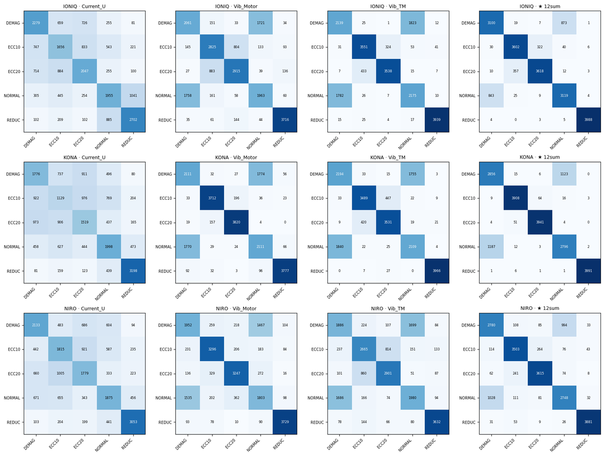

```
저장: C:\Users\jaesung\Desktop\매녀졸프\샘플데이터\03.합성데이터\model\cm_sensor_vs_fusion.png
```

```python
import json, os, numpy as np, matplotlib.pyplot as plt

CLASS_ORDER = ["DEMAG", "ECC10", "ECC20", "NORMAL", "REDUC"]

# {slot_tuple_str: (cm, labels)} 로 모으기
cms = {}
for fname in ["eval_results.json", "fusion_eval.json"]:
    with open(os.path.join(MODEL_DIR, fname), encoding="utf-8") as f:
        for r in json.load(f):
            cm = r.get("confusion_matrix"); labels = r.get("labels"); slot = r.get("slot")
            if cm is None or slot is None:
                continue
            slot = tuple(map(str, slot)) if isinstance(slot, (list, tuple)) else (str(slot),)
            cms[slot] = (np.array(cm, dtype=float), labels)

vehicles = ["IONIQ", "KONA", "NIRO"]
order = ["Current_U", "Vib_Motor", "Vib_TM", "FUSION12"]

def draw(ax, cm, labels, title):
    # 행 정규화(실제 클래스별 비율) → 색이 클래스 불균형에 안 휘둘림
    cmn = cm / cm.sum(axis=1, keepdims=True).clip(min=1)
    ax.imshow(cmn, cmap="Blues", vmin=0, vmax=1)
    ax.set_xticks(range(len(labels))); ax.set_xticklabels(labels, rotation=45, ha="right", fontsize=7)
    ax.set_yticks(range(len(labels))); ax.set_yticklabels(labels, fontsize=7)
    ax.set_title(title, fontsize=9)
    for i in range(len(labels)):
        for j in range(len(labels)):
            ax.text(j, i, int(cm[i, j]), ha="center", va="center", fontsize=6,
                    color="white" if cmn[i, j] > 0.5 else "black")

fig, axes = plt.subplots(len(vehicles), len(order), figsize=(4*len(order), 4*len(vehicles)))
for vi, v in enumerate(vehicles):
    for si, s in enumerate(order):
        ax = axes[vi][si]
        key = (v, s)
        if key in cms:
            cm, labels = cms[key]
            tag = "★ 12sum" if s == "FUSION12" else s
            draw(ax, cm, labels, f"{v} · {tag}")
        else:
            ax.axis("off"); ax.set_title(f"{v} · {s}\n(없음)", fontsize=8)
plt.tight_layout()
plt.savefig(os.path.join(MODEL_DIR, "cm_sensor_vs_fusion.png"), dpi=130, bbox_inches="tight")
plt.show()
print("저장:", os.path.join(MODEL_DIR, "cm_sensor_vs_fusion.png"))
```

```python
import os, joblib

print("=== MODEL_DIR 내용 ===")
for f in os.listdir(MODEL_DIR):
    p = os.path.join(MODEL_DIR, f)
    size = os.path.getsize(p) if os.path.isfile(p) else 0
    print(f"  {f}  ({size/1e6:.2f} MB)" if size else f"  {f}/ (폴더)")

print("\n=== 센서별 모델 ===")
reg = joblib.load(os.path.join(MODEL_DIR, "model_registry.joblib"))
print("슬롯:", list(reg.keys()))
k = list(reg)[0]
print(f"  {k} 파라미터:", list(reg[k].keys()))

print("\n=== 융합 모델 ===")
freg = joblib.load(os.path.join(MODEL_DIR, "fusion_registry.joblib"))
print("슬롯:", list(freg.keys()))
fk = list(freg)[0]
print(f"  {fk} 파라미터:", list(freg[fk].keys()))
print(f"  MiniRocket 입력 채널 수:", freg[fk]["mr"].__dict__.get("n_columns_", "?"), "(융합이면 12)")
```

```
=== MODEL_DIR 내용 ===
  cm_sensor_vs_fusion.png  (0.18 MB)
  eval_results.json  (0.01 MB)
  feature_cache/ (폴더)
  fusion_eval.json  (0.00 MB)
  fusion_registry.joblib  (2.16 MB)
  model_registry.joblib  (6.38 MB)

=== 센서별 모델 ===
슬롯: [('IONIQ', 'Current_U'), ('IONIQ', 'Vib_Motor'), ('IONIQ', 'Vib_TM'), ('KONA', 'Current_U'), ('KONA', 'Vib_Motor'), ('KONA', 'Vib_TM'), ('NIRO', 'Current_U'), ('NIRO', 'Vib_Motor'), ('NIRO', 'Vib_TM')]
  ('IONIQ', 'Current_U') 파라미터: ['ch_mean', 'ch_std', 'mr', 'sc', 'lr', 'classes']

=== 융합 모델 ===
슬롯: [('IONIQ', 'FUSION12'), ('KONA', 'FUSION12'), ('NIRO', 'FUSION12')]
  ('IONIQ', 'FUSION12') 파라미터: ['ch_mean', 'ch_std', 'mr', 'sc', 'lr', 'classes']
  MiniRocket 입력 채널 수: ? (융합이면 12)
```